# Chapter 5

Mohammad Imangholiloo

18 November 2020

# *Exercise 5:* **Dimensionality reduction techniques**

*My GitHub repository is https://github.com/Imangholiloo/IODS-project*  
Nowadays, it’s common to have huge datasets (like Big Data) in which there could be multiple variables with high correlation with each other, or noise within the data. Meaning that, one variable can explain more of the other one. Thus, it is good to reduce the high dimensionality of our data.  
There are many available methods, but we will learn about principal component analysis (PCA), which reduces any number of measured (continuous) and correlated variables into a few uncorrelated components that collect together as much variance as possible from the original variables. And Multiple correspondence analysis (MCA) which gives us similar possibilities in the world of discrete variables, even nominal scale (classified) variables, by finding a suitable transformation into continuous scales and then reducing the dimensions quite analogously with the PCA. *More info: https://vimeo.com/204164956*

## *Part 1) Data wrangling*

```r
#Read the “Human development” file into R
hd <- read.csv("http://s3.amazonaws.com/assets.datacamp.com/production/course_2218/datasets/human_development.csv", stringsAsFactors = F)

#Read the “Gender inequality” file into R
gii <- read.csv("http://s3.amazonaws.com/assets.datacamp.com/production/course_2218/datasets/gender_inequality.csv", stringsAsFactors = F, na.strings = "..")
```

For data description and more info please visit: http://hdr.undp.org/en/content/human-development-index-hdi and http://hdr.undp.org/sites/default/files/hdr2015_technical_notes.pdf

```r
#strcutre of data
str(hd)
```

```
## 'data.frame':    195 obs. of  8 variables:
##  $ HDI.Rank                              : int  1 2 3 4 5 6 6 8 9 9 ...
##  $ Country                               : chr  "Norway" "Australia" "Switzerland" "Denmark" ...
##  $ Human.Development.Index..HDI.         : num  0.944 0.935 0.93 0.923 0.922 0.916 0.916 0.915 0.913 0.913 ...
##  $ Life.Expectancy.at.Birth              : num  81.6 82.4 83 80.2 81.6 80.9 80.9 79.1 82 81.8 ...
##  $ Expected.Years.of.Education           : num  17.5 20.2 15.8 18.7 17.9 16.5 18.6 16.5 15.9 19.2 ...
##  $ Mean.Years.of.Education               : num  12.6 13 12.8 12.7 11.9 13.1 12.2 12.9 13 12.5 ...
##  $ Gross.National.Income..GNI..per.Capita: chr  "64,992" "42,261" "56,431" "44,025" ...
##  $ GNI.per.Capita.Rank.Minus.HDI.Rank    : int  5 17 6 11 9 11 16 3 11 23 ...
```

```r
#dimension of file (row* column)
dim(hd)
```

```
## [1] 195   8
```

```r
#summary of file
summary(hd)
```

```
##     HDI.Rank        Country          Human.Development.Index..HDI.
##  Min.   :  1.00   Length:195         Min.   :0.3480
##  1st Qu.: 47.75   Class :character   1st Qu.:0.5770
##  Median : 94.00   Mode  :character   Median :0.7210
##  Mean   : 94.31                      Mean   :0.6918
##  3rd Qu.:141.25                      3rd Qu.:0.8000
##  Max.   :188.00                      Max.   :0.9440
##  NA's   :7
##  Life.Expectancy.at.Birth Expected.Years.of.Education Mean.Years.of.Education
##  Min.   :49.00            Min.   : 4.10               Min.   : 1.400
##  1st Qu.:65.75            1st Qu.:11.10               1st Qu.: 5.550
##  Median :73.10            Median :13.10               Median : 8.400
##  Mean   :71.07            Mean   :12.86               Mean   : 8.079
##  3rd Qu.:76.80            3rd Qu.:14.90               3rd Qu.:10.600
##  Max.   :84.00            Max.   :20.20               Max.   :13.100
##
##  Gross.National.Income..GNI..per.Capita GNI.per.Capita.Rank.Minus.HDI.Rank
##  Length:195                             Min.   :-84.0000
##  Class :character                       1st Qu.: -9.0000
##  Mode  :character                       Median :  1.5000
##                                         Mean   :  0.1862
##                                         3rd Qu.: 11.0000
##                                         Max.   : 47.0000
##                                         NA's   :7
```

As you can see, our columns are all numerical, except two columns of country and GNI_per_capita, which are class

```r
#column names
colnames(hd)
```

```
## [1] "HDI.Rank"
## [2] "Country"
## [3] "Human.Development.Index..HDI."
## [4] "Life.Expectancy.at.Birth"
## [5] "Expected.Years.of.Education"
## [6] "Mean.Years.of.Education"
## [7] "Gross.National.Income..GNI..per.Capita"
## [8] "GNI.per.Capita.Rank.Minus.HDI.Rank"
```

As you can see, column names are long, so in next phases, we will shorten the names.

```r
#see head and tail of the data
"head(hd)" # I comment these lines out to shorten the report
```

```
## [1] "head(hd)"
```

```r
'tail(hd)'
```

```
## [1] "tail(hd)"
```

```r
#Let's do the same for gii dataset
#strcutre of data
str(gii)
```

```
## 'data.frame':    195 obs. of  10 variables:
##  $ GII.Rank                                    : int  1 2 3 4 5 6 6 8 9 9 ...
##  $ Country                                     : chr  "Norway" "Australia" "Switzerland" "Denmark" ...
##  $ Gender.Inequality.Index..GII.               : num  0.067 0.11 0.028 0.048 0.062 0.041 0.113 0.28 0.129 0.157 ...
##  $ Maternal.Mortality.Ratio                    : int  4 6 6 5 6 7 9 28 11 8 ...
##  $ Adolescent.Birth.Rate                       : num  7.8 12.1 1.9 5.1 6.2 3.8 8.2 31 14.5 25.3 ...
##  $ Percent.Representation.in.Parliament        : num  39.6 30.5 28.5 38 36.9 36.9 19.9 19.4 28.2 31.4 ...
##  $ Population.with.Secondary.Education..Female.: num  97.4 94.3 95 95.5 87.7 96.3 80.5 95.1 100 95 ...
##  $ Population.with.Secondary.Education..Male.  : num  96.7 94.6 96.6 96.6 90.5 97 78.6 94.8 100 95.3 ...
##  $ Labour.Force.Participation.Rate..Female.    : num  61.2 58.8 61.8 58.7 58.5 53.6 53.1 56.3 61.6 62 ...
##  $ Labour.Force.Participation.Rate..Male.      : num  68.7 71.8 74.9 66.4 70.6 66.4 68.1 68.9 71 73.8 ...
```

```r
#dimension of file (row* column)
dim(gii)
```

```
## [1] 195  10
```

```r
#summary of file
summary(gii)
```

```
##     GII.Rank        Country          Gender.Inequality.Index..GII.
##  Min.   :  1.00   Length:195         Min.   :0.0160
##  1st Qu.: 47.75   Class :character   1st Qu.:0.2030
##  Median : 94.00   Mode  :character   Median :0.3935
##  Mean   : 94.31                      Mean   :0.3695
##  3rd Qu.:141.25                      3rd Qu.:0.5272
##  Max.   :188.00                      Max.   :0.7440
##  NA's   :7                           NA's   :33
##  Maternal.Mortality.Ratio Adolescent.Birth.Rate
##  Min.   :   1.0           Min.   :  0.60
##  1st Qu.:  16.0           1st Qu.: 15.45
##  Median :  69.0           Median : 40.95
##  Mean   : 163.2           Mean   : 49.55
##  3rd Qu.: 230.0           3rd Qu.: 71.78
##  Max.   :1100.0           Max.   :204.80
##  NA's   :10               NA's   :5
##  Percent.Representation.in.Parliament
##  Min.   : 0.00
##  1st Qu.:12.47
##  Median :19.50
##  Mean   :20.60
##  3rd Qu.:27.02
##  Max.   :57.50
##  NA's   :3
##  Population.with.Secondary.Education..Female.
##  Min.   :  0.9
##  1st Qu.: 27.8
##  Median : 55.7
##  Mean   : 54.8
##  3rd Qu.: 81.8
##  Max.   :100.0
##  NA's   :26
##  Population.with.Secondary.Education..Male.
##  Min.   :  3.20
##  1st Qu.: 38.30
##  Median : 60.00
##  Mean   : 60.29
##  3rd Qu.: 85.80
##  Max.   :100.00
##  NA's   :26
##  Labour.Force.Participation.Rate..Female.
##  Min.   :13.50
##  1st Qu.:44.50
##  Median :53.30
##  Mean   :52.61
##  3rd Qu.:62.62
##  Max.   :88.10
##  NA's   :11
##  Labour.Force.Participation.Rate..Male.
##  Min.   :44.20
##  1st Qu.:68.88
##  Median :75.55
##  Mean   :74.74
##  3rd Qu.:80.15
##  Max.   :95.50
##  NA's   :11
```

As summary shows, all variables, except country, are numerical variable

```r
#column names
colnames(gii)
```

```
##  [1] "GII.Rank"
##  [2] "Country"
##  [3] "Gender.Inequality.Index..GII."
##  [4] "Maternal.Mortality.Ratio"
##  [5] "Adolescent.Birth.Rate"
##  [6] "Percent.Representation.in.Parliament"
##  [7] "Population.with.Secondary.Education..Female."
##  [8] "Population.with.Secondary.Education..Male."
##  [9] "Labour.Force.Participation.Rate..Female."
## [10] "Labour.Force.Participation.Rate..Male."
```

```r
#see head and tail of the data
'head(gii)' # I comment these lines out to shorten the report
```

```
## [1] "head(gii)"
```

```r
'tail(gii)'
```

```
## [1] "tail(gii)"
```

**Task 4** : rename the variables with (shorter) descriptive names

```r
colnames(hd)
```

```
## [1] "HDI.Rank"
## [2] "Country"
## [3] "Human.Development.Index..HDI."
## [4] "Life.Expectancy.at.Birth"
## [5] "Expected.Years.of.Education"
## [6] "Mean.Years.of.Education"
## [7] "Gross.National.Income..GNI..per.Capita"
## [8] "GNI.per.Capita.Rank.Minus.HDI.Rank"
```

```r
colnames(hd) <- c('HDI_Rank', 'Country', 'HDI', 'Life_Expec_Birth',
                  'Expec_yr_Edu', 'Mean_yr_Edu', 'GNI_per_Cap',
                  'GNI_per_Cap_Min_HDI_Rank')
colnames(hd)
```

```
## [1] "HDI_Rank"                 "Country"
## [3] "HDI"                      "Life_Expec_Birth"
## [5] "Expec_yr_Edu"             "Mean_yr_Edu"
## [7] "GNI_per_Cap"              "GNI_per_Cap_Min_HDI_Rank"
```

so you can see that column names were shorten.

**Let’s do the same for gii dataset**

```r
colnames(gii)
```

```
##  [1] "GII.Rank"
##  [2] "Country"
##  [3] "Gender.Inequality.Index..GII."
##  [4] "Maternal.Mortality.Ratio"
##  [5] "Adolescent.Birth.Rate"
##  [6] "Percent.Representation.in.Parliament"
##  [7] "Population.with.Secondary.Education..Female."
##  [8] "Population.with.Secondary.Education..Male."
##  [9] "Labour.Force.Participation.Rate..Female."
## [10] "Labour.Force.Participation.Rate..Male."
```

```r
colnames(gii) <- c('GII_Rank', 'Country', 'GII', 'Mortality_R',
                  'Adolescent_Birth_R', 'Representation_Parliament',
                  'Sec_Edu_Fem','Sec_Edu_Mal',
                  "Lab_Forc_Particip_R_Fem",
                  "Lab_Forc_Particip_R_Mal" )
colnames(gii)
```

```
##  [1] "GII_Rank"                  "Country"
##  [3] "GII"                       "Mortality_R"
##  [5] "Adolescent_Birth_R"        "Representation_Parliament"
##  [7] "Sec_Edu_Fem"               "Sec_Edu_Mal"
##  [9] "Lab_Forc_Particip_R_Fem"   "Lab_Forc_Particip_R_Mal"
```

So you can see that column names were shorten.

**Task 5** . Mutate the “Gender inequality” data and create two new variables

```r
library(dplyr)
gii <- mutate(gii, edu_R = (Sec_Edu_Fem/Sec_Edu_Mal))
head(gii)
```

```
##   GII_Rank     Country   GII Mortality_R Adolescent_Birth_R
## 1        1      Norway 0.067           4                7.8
## 2        2   Australia 0.110           6               12.1
## 3        3 Switzerland 0.028           6                1.9
## 4        4     Denmark 0.048           5                5.1
## 5        5 Netherlands 0.062           6                6.2
## 6        6     Germany 0.041           7                3.8
##   Representation_Parliament Sec_Edu_Fem Sec_Edu_Mal Lab_Forc_Particip_R_Fem
## 1                      39.6        97.4        96.7                    61.2
## 2                      30.5        94.3        94.6                    58.8
## 3                      28.5        95.0        96.6                    61.8
## 4                      38.0        95.5        96.6                    58.7
## 5                      36.9        87.7        90.5                    58.5
## 6                      36.9        96.3        97.0                    53.6
##   Lab_Forc_Particip_R_Mal     edu_R
## 1                    68.7 1.0072389
## 2                    71.8 0.9968288
## 3                    74.9 0.9834369
## 4                    66.4 0.9886128
## 5                    70.6 0.9690608
## 6                    66.4 0.9927835
```

### **Extra coding 1: alternative to mutate function**

instead of using mutate, this is also possible:

```r
gii$edu_R <- gii$Sec_Edu_Fem/gii$Sec_Edu_Mal

gii <- mutate(gii, Lab_Forc_R = (Lab_Forc_Particip_R_Fem/Lab_Forc_Particip_R_Mal))
head(gii)
```

```
##   GII_Rank     Country   GII Mortality_R Adolescent_Birth_R
## 1        1      Norway 0.067           4                7.8
## 2        2   Australia 0.110           6               12.1
## 3        3 Switzerland 0.028           6                1.9
## 4        4     Denmark 0.048           5                5.1
## 5        5 Netherlands 0.062           6                6.2
## 6        6     Germany 0.041           7                3.8
##   Representation_Parliament Sec_Edu_Fem Sec_Edu_Mal Lab_Forc_Particip_R_Fem
## 1                      39.6        97.4        96.7                    61.2
## 2                      30.5        94.3        94.6                    58.8
## 3                      28.5        95.0        96.6                    61.8
## 4                      38.0        95.5        96.6                    58.7
## 5                      36.9        87.7        90.5                    58.5
## 6                      36.9        96.3        97.0                    53.6
##   Lab_Forc_Particip_R_Mal     edu_R Lab_Forc_R
## 1                    68.7 1.0072389  0.8908297
## 2                    71.8 0.9968288  0.8189415
## 3                    74.9 0.9834369  0.8251001
## 4                    66.4 0.9886128  0.8840361
## 5                    70.6 0.9690608  0.8286119
## 6                    66.4 0.9927835  0.8072289
```

**Task 6** .Join together the two datasets using the variable Country as the identifier  
**TIP** we use inner join to keep only observations in both data sets

```r
hd_gii_joint <- inner_join(hd, gii,
                           by = 'Country', suffix = c("_hd", "_gi"))

'head(hd_gii_joint)' # I comment theis line out to shorten the
```

```
## [1] "head(hd_gii_joint)"
```

```r
dim(hd_gii_joint)
```

```
## [1] 195  19
```

```r
str(hd_gii_joint)
```

```
## 'data.frame':    195 obs. of  19 variables:
##  $ HDI_Rank                 : int  1 2 3 4 5 6 6 8 9 9 ...
##  $ Country                  : chr  "Norway" "Australia" "Switzerland" "Denmark" ...
##  $ HDI                      : num  0.944 0.935 0.93 0.923 0.922 0.916 0.916 0.915 0.913 0.913 ...
##  $ Life_Expec_Birth         : num  81.6 82.4 83 80.2 81.6 80.9 80.9 79.1 82 81.8 ...
##  $ Expec_yr_Edu             : num  17.5 20.2 15.8 18.7 17.9 16.5 18.6 16.5 15.9 19.2 ...
##  $ Mean_yr_Edu              : num  12.6 13 12.8 12.7 11.9 13.1 12.2 12.9 13 12.5 ...
##  $ GNI_per_Cap              : chr  "64,992" "42,261" "56,431" "44,025" ...
##  $ GNI_per_Cap_Min_HDI_Rank : int  5 17 6 11 9 11 16 3 11 23 ...
##  $ GII_Rank                 : int  1 2 3 4 5 6 6 8 9 9 ...
##  $ GII                      : num  0.067 0.11 0.028 0.048 0.062 0.041 0.113 0.28 0.129 0.157 ...
##  $ Mortality_R              : int  4 6 6 5 6 7 9 28 11 8 ...
##  $ Adolescent_Birth_R       : num  7.8 12.1 1.9 5.1 6.2 3.8 8.2 31 14.5 25.3 ...
##  $ Representation_Parliament: num  39.6 30.5 28.5 38 36.9 36.9 19.9 19.4 28.2 31.4 ...
##  $ Sec_Edu_Fem              : num  97.4 94.3 95 95.5 87.7 96.3 80.5 95.1 100 95 ...
##  $ Sec_Edu_Mal              : num  96.7 94.6 96.6 96.6 90.5 97 78.6 94.8 100 95.3 ...
##  $ Lab_Forc_Particip_R_Fem  : num  61.2 58.8 61.8 58.7 58.5 53.6 53.1 56.3 61.6 62 ...
##  $ Lab_Forc_Particip_R_Mal  : num  68.7 71.8 74.9 66.4 70.6 66.4 68.1 68.9 71 73.8 ...
##  $ edu_R                    : num  1.007 0.997 0.983 0.989 0.969 ...
##  $ Lab_Forc_R               : num  0.891 0.819 0.825 0.884 0.829 ...
```

```r
#setwd("./data")
write.csv(hd_gii_joint, "./data/human.csv")
```

## *Data wrangling* `(for this week)`

Now in this week, lets continue to data wrangling and analysis in theme of dimensionality reduction

```r
human <- read.csv("./data/human.csv")
#altrnatively, you can read directly from web:
human <- read.table("http://s3.amazonaws.com/assets.datacamp.com/production/course_2218/datasets/human1.txt", sep  =",", header = T)

# check column names of the data
names(human)
```

```
##  [1] "HDI.Rank"       "Country"        "HDI"            "Life.Exp"
##  [5] "Edu.Exp"        "Edu.Mean"       "GNI"            "GNI.Minus.Rank"
##  [9] "GII.Rank"       "GII"            "Mat.Mor"        "Ado.Birth"
## [13] "Parli.F"        "Edu2.F"         "Edu2.M"         "Labo.F"
## [17] "Labo.M"         "Edu2.FM"        "Labo.FM"
```

```r
#dimention of dataset
dim(human)
```

```
## [1] 195  19
```

**Data description:**  
This data originates from the United Nations Development Programme. It gives us information about Human Development status in different countries by different variables.  
The data combines several indicators from most countries in the world. *More info in http://hdr.undp.org/en/content/human-development-index-hdi*

The variables names and their descriptions are as following: “Country” = Country name

Health and knowledge  
“GNI” = Gross National Income per capita  
“Life.Exp” = Life expectancy at birth  
“Edu.Exp” = Expected years of schooling  
“Mat.Mor” = Maternal mortality ratio  
“Ado.Birth” = Adolescent birth rate

Empowerment  
“Parli.F” = Percentage of female representatives in parliament  
“Edu2.F” = Proportion of females with at least secondary education  
“Edu2.M” = Proportion of males with at least secondary education  
“Labo.F” = Proportion of females in the labour force  
“Labo.M” " Proportion of males in the labour force

“Edu2.FM” = Edu2.F / Edu2.M  
“Labo.FM” = Labo2.F / Labo2.M"

NOTE: Since I personally do not like dots (.) to be in the file or columns names, I like to change it to underscore (_)

```r
colnames(human) <- c("HDI_Rank", "Country", "HDI", "Life_Exp",
                   "Edu_Exp", "Edu_Mean", "GNI", "GNI_Minus_Rank",
                   "GII_Rank","GII","Mat_Mor","Ado_Birth",
                   "Parli_F","Edu2_F","Edu2_M","Labo_F",
                   "Labo_M","Edu2_FM","Labo_FM")
#Source: https://raw.githubusercontent.com/TuomoNieminen/Helsinki-Open-Data-Science/master/datasets/human_meta.txt

# Check Column names again that changed successfully
colnames(human)
```

```
##  [1] "HDI_Rank"       "Country"        "HDI"            "Life_Exp"
##  [5] "Edu_Exp"        "Edu_Mean"       "GNI"            "GNI_Minus_Rank"
##  [9] "GII_Rank"       "GII"            "Mat_Mor"        "Ado_Birth"
## [13] "Parli_F"        "Edu2_F"         "Edu2_M"         "Labo_F"
## [17] "Labo_M"         "Edu2_FM"        "Labo_FM"
```

```r
# look at the structure of human
'str(human)' # I comment this line out to shorten the
```

```
## [1] "str(human)"
```

```r
# print out summaries of the variables
summary(human)
```

```
##     HDI_Rank        Country               HDI            Life_Exp
##  Min.   :  1.00   Length:195         Min.   :0.3480   Min.   :49.00
##  1st Qu.: 47.75   Class :character   1st Qu.:0.5770   1st Qu.:65.75
##  Median : 94.00   Mode  :character   Median :0.7210   Median :73.10
##  Mean   : 94.31                      Mean   :0.6918   Mean   :71.07
##  3rd Qu.:141.25                      3rd Qu.:0.8000   3rd Qu.:76.80
##  Max.   :188.00                      Max.   :0.9440   Max.   :84.00
##  NA's   :7
##     Edu_Exp         Edu_Mean          GNI            GNI_Minus_Rank
##  Min.   : 4.10   Min.   : 1.400   Length:195         Min.   :-84.0000
##  1st Qu.:11.10   1st Qu.: 5.550   Class :character   1st Qu.: -9.0000
##  Median :13.10   Median : 8.400   Mode  :character   Median :  1.5000
##  Mean   :12.86   Mean   : 8.079                      Mean   :  0.1862
##  3rd Qu.:14.90   3rd Qu.:10.600                      3rd Qu.: 11.0000
##  Max.   :20.20   Max.   :13.100                      Max.   : 47.0000
##                                                      NA's   :7
##     GII_Rank           GII            Mat_Mor         Ado_Birth
##  Min.   :  1.00   Min.   :0.0160   Min.   :   1.0   Min.   :  0.60
##  1st Qu.: 47.75   1st Qu.:0.2030   1st Qu.:  16.0   1st Qu.: 15.45
##  Median : 94.00   Median :0.3935   Median :  69.0   Median : 40.95
##  Mean   : 94.31   Mean   :0.3695   Mean   : 163.2   Mean   : 49.55
##  3rd Qu.:141.25   3rd Qu.:0.5272   3rd Qu.: 230.0   3rd Qu.: 71.78
##  Max.   :188.00   Max.   :0.7440   Max.   :1100.0   Max.   :204.80
##  NA's   :7        NA's   :33       NA's   :10       NA's   :5
##     Parli_F          Edu2_F          Edu2_M           Labo_F
##  Min.   : 0.00   Min.   :  0.9   Min.   :  3.20   Min.   :13.50
##  1st Qu.:12.47   1st Qu.: 27.8   1st Qu.: 38.30   1st Qu.:44.50
##  Median :19.50   Median : 55.7   Median : 60.00   Median :53.30
##  Mean   :20.60   Mean   : 54.8   Mean   : 60.29   Mean   :52.61
##  3rd Qu.:27.02   3rd Qu.: 81.8   3rd Qu.: 85.80   3rd Qu.:62.62
##  Max.   :57.50   Max.   :100.0   Max.   :100.00   Max.   :88.10
##  NA's   :3       NA's   :26      NA's   :26       NA's   :11
##      Labo_M         Edu2_FM          Labo_FM
##  Min.   :44.20   Min.   :0.1717   Min.   :0.1857
##  1st Qu.:68.88   1st Qu.:0.7284   1st Qu.:0.5987
##  Median :75.55   Median :0.9349   Median :0.7514
##  Mean   :74.74   Mean   :0.8541   Mean   :0.7038
##  3rd Qu.:80.15   3rd Qu.:0.9968   3rd Qu.:0.8513
##  Max.   :95.50   Max.   :1.4967   Max.   :1.0380
##  NA's   :11      NA's   :26       NA's   :11
```

The summary shows the minimum, maximum, mean, and 1st and 3rd quartiles of the data together with median. It also shows if there as NA cells in our columns. Moreover, we can see that all variables, except Country and GNI index, are numerical

**Task 1** : Mutate the data: transform the Gross National Income (GNI) variable to numeric"

```r
# access the stringr package
library(stringr)

# look at the structure of the GNI column in 'human'
str(human$GNI)
```

```
##  chr [1:195] "64,992" "42,261" "56,431" "44,025" "45,435" "43,919" "39,568" ...
```

```r
class(human$GNI)
```

```
## [1] "character"
```

As you can see, this GNI column is not numerical (is character class), so we shall change it as numeric.

```r
# remove the commas from GNI and print out a numeric version of it
human$GNI <- str_replace(human$GNI, pattern=",", replace ="") %>% as.numeric

str(human$GNI)
```

```
##  num [1:195] 64992 42261 56431 44025 45435 ...
```

```r
class(human$GNI)
```

```
## [1] "numeric"
```

**Task 2**: keep only the columns matching the following variable names"

```r
# columns to keep
keep <- c("Country", "Edu2_FM", "Labo_FM", "Life_Exp", "Edu_Exp",
          "GNI", "Mat_Mor", "Ado_Birth", "Parli_F")

# select the 'keep' columns
human <- dplyr::select(human, one_of(keep))

length(keep)
```

```
## [1] 9
```

```r
ncol(human)
```

```
## [1] 9
```

So the number of columns of dataset is now equal to the number of variables we like to keep.

**Task 3** : Remove all rows with missing values

```r
# print out a completeness indicator of the 'human' data
complete.cases(human)
```

```
##   [1]  TRUE  TRUE  TRUE  TRUE  TRUE  TRUE  TRUE  TRUE  TRUE  TRUE  TRUE FALSE
##  [13] FALSE  TRUE  TRUE  TRUE  TRUE  TRUE  TRUE  TRUE  TRUE  TRUE  TRUE  TRUE
##  [25]  TRUE  TRUE  TRUE  TRUE  TRUE  TRUE FALSE  TRUE  TRUE FALSE  TRUE  TRUE
##  [37]  TRUE  TRUE  TRUE  TRUE  TRUE  TRUE  TRUE  TRUE  TRUE  TRUE  TRUE  TRUE
##  [49]  TRUE  TRUE  TRUE  TRUE  TRUE  TRUE  TRUE  TRUE  TRUE FALSE  TRUE FALSE
##  [61]  TRUE  TRUE  TRUE FALSE  TRUE  TRUE  TRUE  TRUE  TRUE  TRUE  TRUE  TRUE
##  [73]  TRUE  TRUE  TRUE  TRUE FALSE  TRUE FALSE  TRUE  TRUE  TRUE  TRUE  TRUE
##  [85]  TRUE  TRUE  TRUE  TRUE FALSE  TRUE  TRUE  TRUE  TRUE FALSE  TRUE  TRUE
##  [97]  TRUE FALSE  TRUE  TRUE  TRUE  TRUE  TRUE  TRUE  TRUE  TRUE  TRUE  TRUE
## [109] FALSE  TRUE  TRUE  TRUE FALSE FALSE  TRUE  TRUE  TRUE  TRUE  TRUE  TRUE
## [121]  TRUE FALSE FALSE  TRUE  TRUE  TRUE  TRUE  TRUE  TRUE  TRUE  TRUE  TRUE
## [133] FALSE  TRUE FALSE  TRUE FALSE FALSE  TRUE  TRUE FALSE  TRUE  TRUE FALSE
## [145]  TRUE  TRUE  TRUE  TRUE FALSE  TRUE  TRUE FALSE  TRUE FALSE  TRUE  TRUE
## [157] FALSE  TRUE FALSE  TRUE  TRUE  TRUE  TRUE  TRUE  TRUE  TRUE  TRUE FALSE
## [169] FALSE  TRUE  TRUE  TRUE  TRUE  TRUE  TRUE  TRUE  TRUE FALSE  TRUE  TRUE
## [181]  TRUE FALSE  TRUE  TRUE  TRUE FALSE  TRUE  TRUE  TRUE  TRUE  TRUE  TRUE
## [193]  TRUE  TRUE  TRUE
```

`complete.cases` function Return a logical vector indicating which cases are complete, i.e., have no missing values

```r
# filter out all rows with NA values
human_filterd <- filter(human, complete.cases(human))
dim(human_filterd)
```

```
## [1] 162   9
```

```r
dim(human)
```

```
## [1] 195   9
```

So you can see that the original human dataset had 195 rows, an now has 162.

### **Extra coding 2: alternatively, you could do with the following code too**

```r
library(tidyverse)
human_filterd_new = human %>% drop_na()
dim(human_filterd_new)
```

```
## [1] 162   9
```

```r
#Or alternatively same
human_ = human %>% drop_na(colnames(human))
dim(human_)
```

```
## [1] 162   9
```

**Task 4**: Remove the observations which relate to regions instead of countries

```r
#look at the last 10 observations
tail(human_filterd, 10)
```

```
##                             Country   Edu2_FM   Labo_FM Life_Exp Edu_Exp   GNI
## 153                            Chad 0.1717172 0.8080808     51.6     7.4  2085
## 154        Central African Republic 0.3782772 0.8531140     50.7     7.2   581
## 155                           Niger 0.3076923 0.4459309     61.4     5.4   908
## 156                     Arab States 0.7289916 0.3081009     70.6    12.0 15722
## 157       East Asia and the Pacific 0.8250377 0.7884131     74.0    12.7 11449
## 158         Europe and Central Asia 0.8784119 0.6514286     72.3    13.6 12791
## 159 Latin America and the Caribbean 0.9836957 0.6729323     75.0    14.0 14242
## 160                      South Asia 0.5329670 0.3711083     68.4    11.2  5605
## 161              Sub-Saharan Africa 0.7015873 0.8537859     58.5     9.6  3363
## 162                           World 0.8333333 0.6558018     71.5    12.2 14301
##     Mat_Mor Ado_Birth Parli_F
## 153     980     152.0    14.9
## 154     880      98.3    12.5
## 155     630     204.8    13.3
## 156     155      45.4    14.0
## 157      72      21.2    18.7
## 158      28      30.8    19.0
## 159      85      68.3    27.0
## 160     183      38.7    17.5
## 161     506     109.7    22.5
## 162     210      47.4    21.8
```

```r
# last indice we want to keep
last <- nrow(human_filterd) - 7

# choose everything until the last 7 observations
human_ <- human_filterd[1:last, ]
```

**Task 5**. Define the row names of the data by the country names

```r
# add countries as rownames
rownames(human_filterd) <- human_filterd$Country

# remove the Country variable
human_ <- select(human_filterd, -Country)

# load library
library(GGally)
```

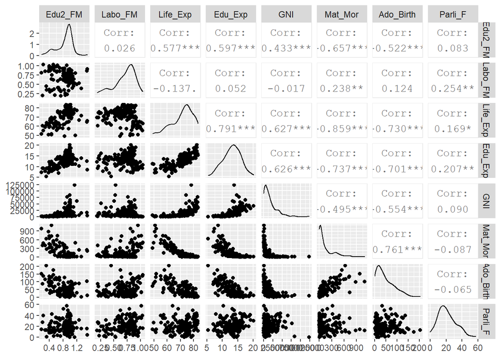

```r
library(corrplot)
# visualize the 'human_' variables
ggpairs(human_)
```

As the graph shows, there is strong correlation between some variables such as ado_birth abd mat_mor and edu_exp. similarly, GNI and life_exp and edu_exp.

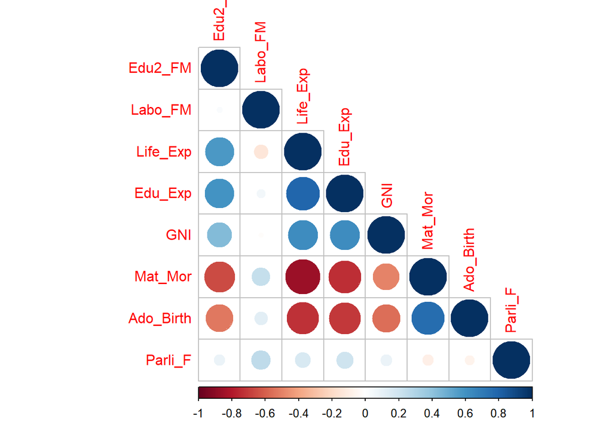

```r
# compute the correlation matrix and visualize it with corrplot
cor(human_) %>% corrplot(type = "lower")
```

```r
write.csv(human_, "human_new.csv")
```

## *Part 2) Data analysis*

```r
human <- read.csv("human_new.csv")
# Alternatively, yu can read directly from web
human <- read.csv("http://s3.amazonaws.com/assets.datacamp.com/production/course_2218/datasets/human2.txt", sep = ",", stringsAsFactors = F)
dim(human)
```

```
## [1] 155   8
```

**Task 1** : Show a graphical overview

```r
# standardize the variables
human_std <- scale(human)
```

As `center = True` (by default), now, this scale is done now by cantering which is done by subtracting the column means (omitting NAs) of x from their corresponding columns.  
We standardize the data, because PCA is sensitive to relative scaling od the orignal features.

```r
# print out summaries of the standardized variables
summary(human_std)
```

```
##     Edu2.FM           Labo.FM           Edu.Exp           Life.Exp
##  Min.   :-2.8189   Min.   :-2.6247   Min.   :-2.7378   Min.   :-2.7188
##  1st Qu.:-0.5233   1st Qu.:-0.5484   1st Qu.:-0.6782   1st Qu.:-0.6425
##  Median : 0.3503   Median : 0.2316   Median : 0.1140   Median : 0.3056
##  Mean   : 0.0000   Mean   : 0.0000   Mean   : 0.0000   Mean   : 0.0000
##  3rd Qu.: 0.5958   3rd Qu.: 0.7350   3rd Qu.: 0.7126   3rd Qu.: 0.6717
##  Max.   : 2.6646   Max.   : 1.6632   Max.   : 2.4730   Max.   : 1.4218
##       GNI             Mat.Mor          Ado.Birth          Parli.F
##  Min.   :-0.9193   Min.   :-0.6992   Min.   :-1.1325   Min.   :-1.8203
##  1st Qu.:-0.7243   1st Qu.:-0.6496   1st Qu.:-0.8394   1st Qu.:-0.7409
##  Median :-0.3013   Median :-0.4726   Median :-0.3298   Median :-0.1403
##  Mean   : 0.0000   Mean   : 0.0000   Mean   : 0.0000   Mean   : 0.0000
##  3rd Qu.: 0.3712   3rd Qu.: 0.1932   3rd Qu.: 0.6030   3rd Qu.: 0.6127
##  Max.   : 5.6890   Max.   : 4.4899   Max.   : 3.8344   Max.   : 3.1850
```

```r
summary(human)
```

```
##     Edu2.FM          Labo.FM          Edu.Exp         Life.Exp
##  Min.   :0.1717   Min.   :0.1857   Min.   : 5.40   Min.   :49.00
##  1st Qu.:0.7264   1st Qu.:0.5984   1st Qu.:11.25   1st Qu.:66.30
##  Median :0.9375   Median :0.7535   Median :13.50   Median :74.20
##  Mean   :0.8529   Mean   :0.7074   Mean   :13.18   Mean   :71.65
##  3rd Qu.:0.9968   3rd Qu.:0.8535   3rd Qu.:15.20   3rd Qu.:77.25
##  Max.   :1.4967   Max.   :1.0380   Max.   :20.20   Max.   :83.50
##       GNI            Mat.Mor         Ado.Birth         Parli.F
##  Min.   :   581   Min.   :   1.0   Min.   :  0.60   Min.   : 0.00
##  1st Qu.:  4198   1st Qu.:  11.5   1st Qu.: 12.65   1st Qu.:12.40
##  Median : 12040   Median :  49.0   Median : 33.60   Median :19.30
##  Mean   : 17628   Mean   : 149.1   Mean   : 47.16   Mean   :20.91
##  3rd Qu.: 24512   3rd Qu.: 190.0   3rd Qu.: 71.95   3rd Qu.:27.95
##  Max.   :123124   Max.   :1100.0   Max.   :204.80   Max.   :57.50
```

As you can see from the summary of scaled and not-scaled data, the scaled one is standardized based on mean of each column, so data are not heteroscedasticity effect. So, we are not ready for further analysis.

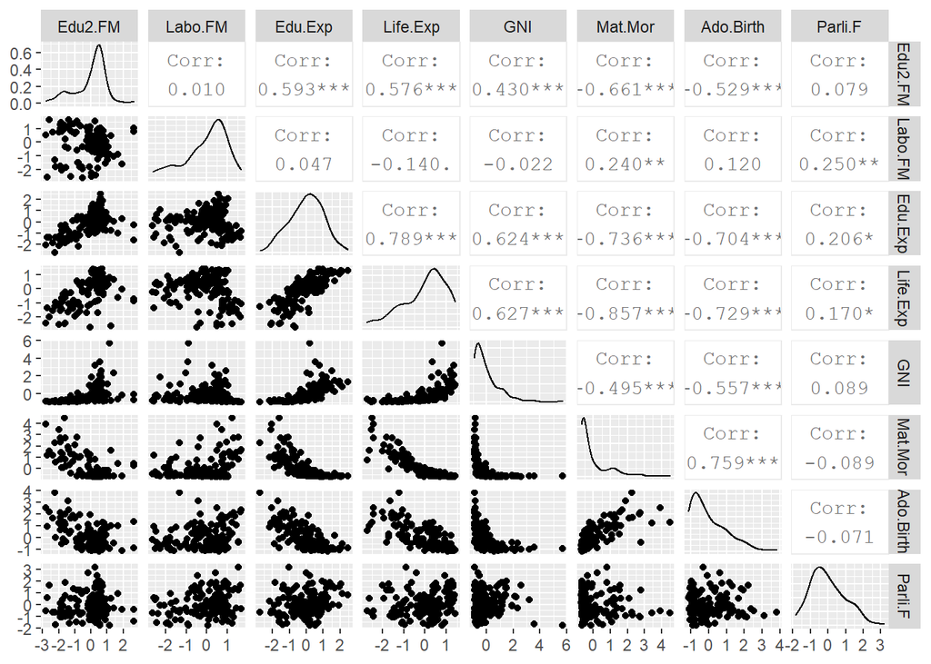

```r
ggpairs(as.data.frame(human_std))
```

This visualises the data distribution for each column and comparing with other columns.

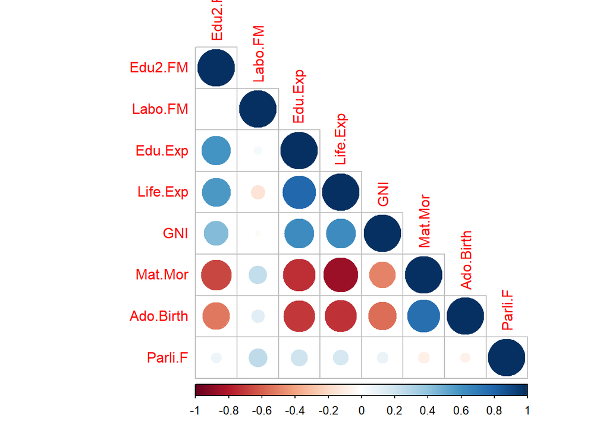

```r
cor(as.data.frame(human_std)) %>% corrplot(type = "lower")
```

The correction matrix (same as above) is given here, same interpretation as in data wrangling part

**Task 2** Perform principal component analysis (PCA) with the SVD method  
As instructed, we do PCA on not standardized human data.

```r
pca_human <- prcomp(human)
summary(pca_human)
```

```
## Importance of components:
##                              PC1      PC2   PC3   PC4   PC5   PC6    PC7    PC8
## Standard deviation     1.854e+04 185.5219 25.19 11.45 3.766 1.566 0.1912 0.1591
## Proportion of Variance 9.999e-01   0.0001  0.00  0.00 0.000 0.000 0.0000 0.0000
## Cumulative Proportion  9.999e-01   1.0000  1.00  1.00 1.000 1.000 1.0000 1.0000
```

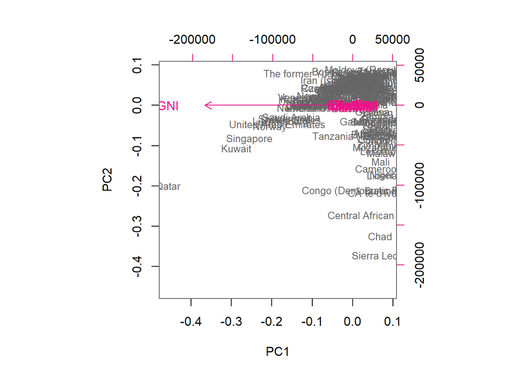

```r
# Draw a biplot displaying the observations by the first two principal components (PC1 coordinate in x-axis, PC2 coordinate in y-axis)
biplot(pca_human, choices = 1:2, cex = c(0.8, 1), col = c("grey40", "deeppink2"))
```

The arrows show the original variables (there are overlapping on each other).

**Task 3** Perfom PCa with standardize variables

```r
pca_human <- prcomp(human_std)
summary(pca_human)
```

```
## Importance of components:
##                           PC1    PC2     PC3     PC4     PC5     PC6     PC7
## Standard deviation     2.0708 1.1397 0.87505 0.77886 0.66196 0.53631 0.45900
## Proportion of Variance 0.5361 0.1624 0.09571 0.07583 0.05477 0.03595 0.02634
## Cumulative Proportion  0.5361 0.6984 0.79413 0.86996 0.92473 0.96069 0.98702
##                            PC8
## Standard deviation     0.32224
## Proportion of Variance 0.01298
## Cumulative Proportion  1.00000
```

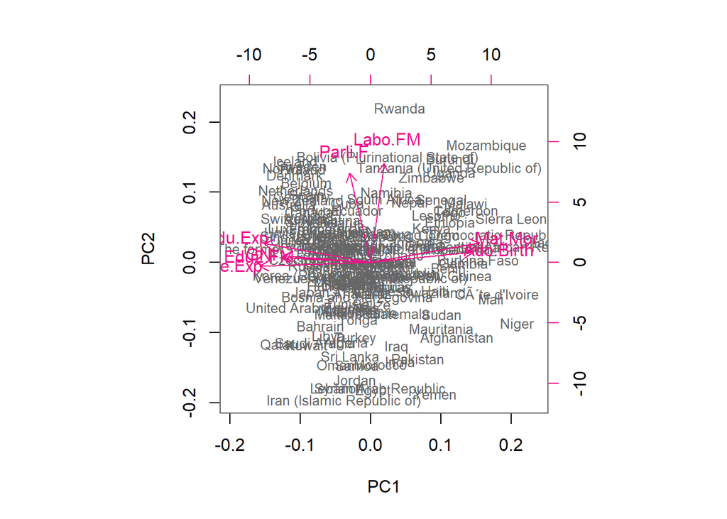

```r
# Draw a biplot displaying the observations by the first two principal components (PC1 coordinate in x-axis, PC2 coordinate in y-axis)
biplot(pca_human, choices = 1:2, cex = c(0.8, 1), col = c("grey40", "deeppink2"))
```

The arrows show the original variables

```r
# rounded percentages of variance captured by each PC
pca_pr <- round(100*summary(pca_human)$importance[2,], digits = 1)
pca_pr
```

```
##  PC1  PC2  PC3  PC4  PC5  PC6  PC7  PC8
## 53.6 16.2  9.6  7.6  5.5  3.6  2.6  1.3
```

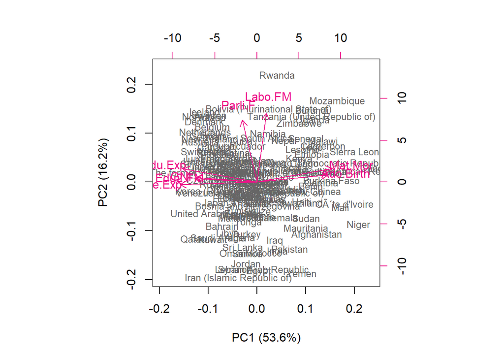

```r
# create object pc_lab to be used as axis labels
pc_lab <- paste0(names(pca_pr), " (", pca_pr, "%)")

# draw a biplot
biplot(pca_human, cex = c(0.8, 1), col = c("grey40", "deeppink2"), xlab = pc_lab[1], ylab = pc_lab[2])
```

**Task 4:** I personally think that using PCA is very useful because cool and very useful also in my own research in forest data science where I often have tens of variables. PCA 1 and PCA 2 together show/contribute to nearly 70% (53.6+16.2) of the variance in the original data.